# Spatio-temporal disease mapping with `R-INLA`

Julien Riou

2024-03-07

# 1 Bayesian inference and `INLA`

Very short reminder about Bayesian inference:

- alternative to frequentist inference
- infer parameter values by integrating data and domain knowledge
- consider all unknown parameters as random variables (i.e., their values have a probability distribution)
- more efficient for complex models (high dimensionality)
- rigorously quantify and propagate uncertainty into parameter estimates and predictions

Many excellent resources to learn more (Gelman et al. 1995; McElreath 2016 ; Gómez-Rubio 2021).

## 1.1 Likelihood-based inference

The general principle of Bayesian inference can be expressed using conditional probabilities. Consider data $y = \{y_1,...,y_n\}$ that are all observations from a common mean $\theta$ based on a normal distribution with known standard deviation. This could for instance be measurements of the height of 100 people taken randomly among Swiss adults, so that $\theta$ is the (unknown) average height in this population. We can simulate some data to make it more concrete.

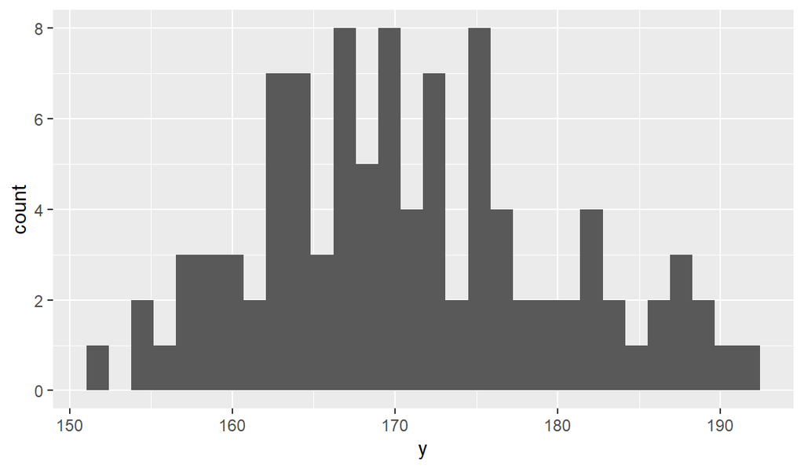

```r
set.seed(217)
n = 100
true_theta = 170
true_sigma = 10
y = rnorm(n, mean=true_theta, sd=true_sigma)
ggplot(tibble(y=y),aes(y)) + geom_histogram(bins=30)
```

This is also called the **likelihood**. It can be interpreted as the probability of observing data $y$ for every value of $\theta$. It describes the data generating process given the parameters. We can compute the likelihood for our simple example (it’s easier done on the log scale).

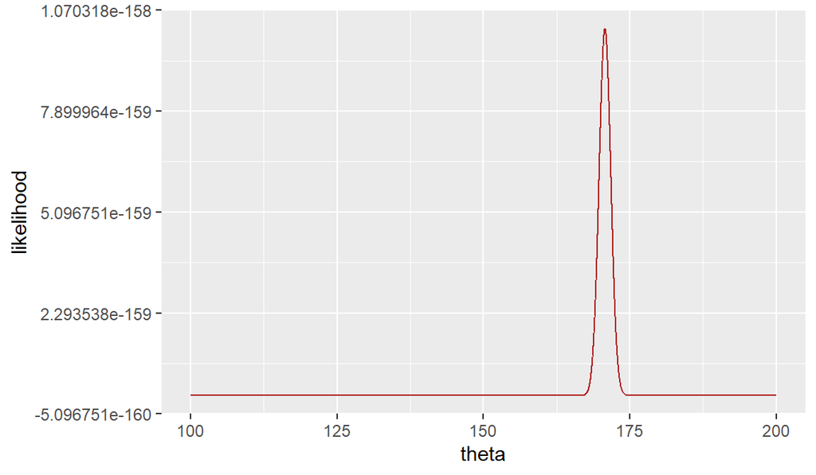

```r
log_likelihood = function(par) {
  loglik = sum(dnorm(y,par,true_sigma,log=TRUE))
  return(loglik)
}
theta = seq(100,200,by=.01)
loglik = unlist(lapply(theta,log_likelihood))
lik_values = tibble(theta=theta,loglik=loglik) %>%
  mutate(likelihood=exp(loglik))
ggplot(lik_values,aes(theta,likelihood)) + geom_line(colour="firebrick")
```

We obtain the probability of observing the data $y$ for each value of unknown $\theta$ between 100 and 200. If we were to take the mode of this likelihood function, this would correspond to the **maximum likelihood** estimate of $\theta$ often used in frequentist inference.

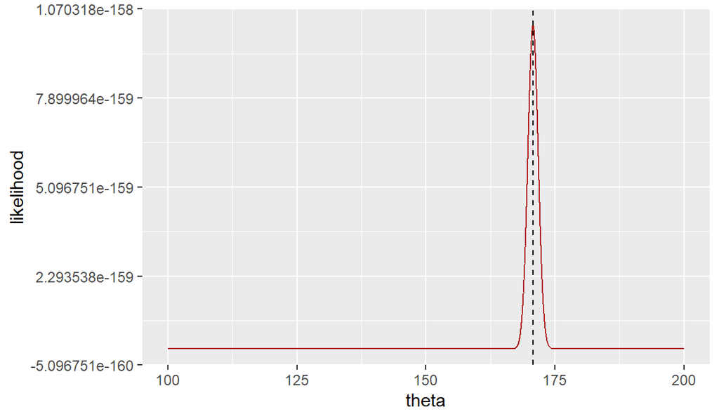

```r
lik_mode = lik_values$theta[which.max(lik_values$likelihood)]
ggplot(lik_values,aes(theta,likelihood)) + geom_line(colour="firebrick") +
  geom_vline(xintercept=lik_mode,linetype=2)
```

```r
lik_mode
```

```
## [1] 170.78
```

## 1.2 Bayes rule

However, in Bayesian inference we don’t want to just get a point estimate, we want to look at the entire distribution of plausible values for $\theta$. In mathematical notation, the likelihood is:

$$\Pr(y | \theta)$$

but what we want to obtain is:

$$\Pr(\theta | y),$$

the probability distribution of the values of $\theta$ given the data $y$. This is called the **posterior distribution**, and this can be obtained using Bayes rule (hence Bayesian inference):

$$\Pr(\theta|y) = \frac{\Pr(y|\theta) \Pr(\theta)}{\Pr(y)}.$$

In addition to the posterior distribution and the likelihood, we see two additional elements. The denominator $\Pr(y)$ can be left aside, as it can be thought of as just a normalizing constant (it does not depend on $\theta$).

The **prior distribution** $\Pr(\theta)$, on the opposite, is very interesting. It can be interpreted as the existing knowledge about $\theta$ before observing the data. In a way, we combine the prior distribution and the likelihood (and normalize it) to obtain the posterior distribution.

## 1.3 Prior distribution

The prior distribution can be very flat, just bounded by mathematical constraints (e.g., $\theta$ is a positive number), in which case it’s called *non-informative* or *vague*.

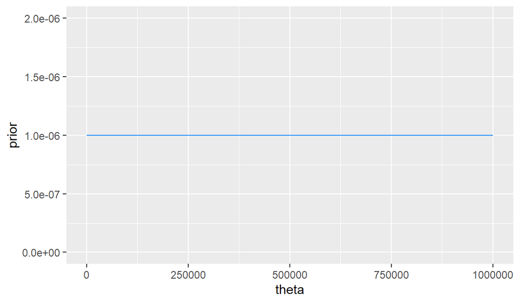

```r
tibble(theta=seq(0,1e6,by=100)) %>%
  mutate(prior=1/1e6) %>%
  ggplot(aes(theta,prior)) + geom_line(colour="dodgerblue") + coord_cartesian(ylim=c(0,2/1e6))
```

It can be a bit more interesting, e.g. including some real-world constraints. So if $\theta$ is an average height in a population of humans, it should be somewhere between the smallest human (Jyoti Amge, 63 cm) and the tallest human (Sultan Kosen, 246 cm). In that case the prior would be called *weakly-informative*.

[figure not shown]

Figure. *Jyoti Amge, the smallest adult woman in the world, and Sultan Kosen, the tallest man in the world, visiting the pyramids.*

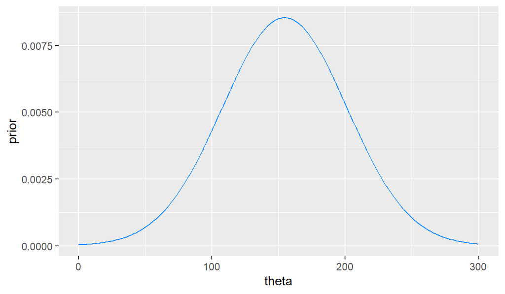

```r
bounds = c(63,246)
tibble(theta=seq(0,300,by=1)) %>%
  mutate(prior=dnorm(theta,mean=mean(bounds),sd=diff(bounds)/(2*1.96))) %>%
  ggplot(aes(theta,prior)) + geom_line(colour="dodgerblue")
```

The prior can also be the posterior from previous estimations of the same parameter, in which case, it can be designed as *informative*. This idea is related to the concept of Bayesian updating, whereby additional data can be added sequentially to improve the estimation.

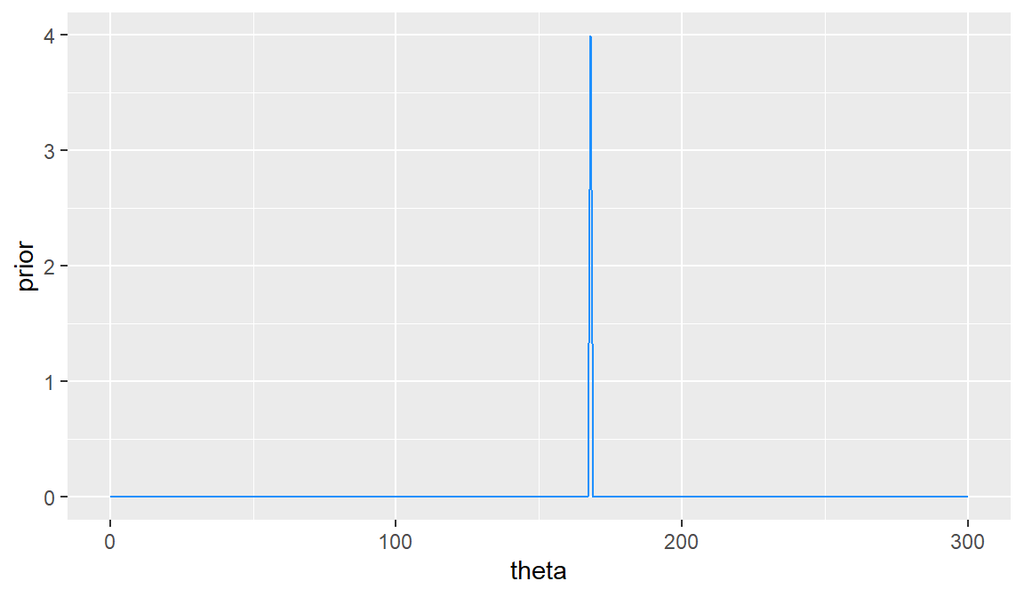

```r
previous_theta = 168
tibble(theta=seq(0,300,by=1)) %>%
  mutate(prior=dnorm(theta,mean=previous_theta,sd=0.1)) %>%
  ggplot(aes(theta,prior)) + geom_line(colour="dodgerblue")
```

Last, priors are sometimes chosen for practical reasons, because they make the computation of the posterior distribution simple (e.g. conjugate priors even make it closed-form) or easier (e.g. penalized complexity priors).

## 1.4 Computing the posterior with MCMC

In most cases though the posterior distribution cannot be directly calculated (in particular because of $\Pr(y)$). A common approach is to learn about the posterior distribution by drawing samples from it, which is often possible without knowing its exact expression. This is the basis of **Monte Carlo** methods, that have applications in many areas.

[figure not shown]

Figure. *Monte Carlo approach to determine the area of a lake using random artillery fire.*

Markov chain Monte Carlo (MCMC) methods apply a similar principle to probability distributions. MCMC algorithms explore the posterior distribution with samples, asymptotically approximating the unknown true distribution. Several MCMC algorithms exist, with different implementations in `R` (e.g., `BUGS`,`Stan`, `JAGS`, `nimble`…).

[figure not shown]

Figure. *A Metropolis-Hastings algorithms exploring a bivariate normal target distribution (https://chi-feng.github.io/mcmc-demo/app.html).*

We can apply MCMC to our simple example, for instance with package `brms` (that uses `Stan` under the hood). The installation of `brms` can be long, and it’s not the main topic here, so there is no need to run the next chunk.

```r
if(FALSE) {
  library(brms)
  # with the weakly-informative prior based on the smallest and tallest humans
  weakly_informative_prior =  brms::set_prior("normal(154.5,47)", class="Intercept")
  mcmc_estimate_wif = brms::brm(y~1,
                                family=gaussian(),
                                prior=weakly_informative_prior,
                                data=tibble(y=y))
  summary(mcmc_estimate_wif)
}
```

[figure not shown]

## 1.5 Integrated Laplace approximation

MCMC is very effective but computationally intensive. `R-INLA` uses a different approach called *integrated nested Laplace approximation* (Rue, Martino, and Chopin 2009). The approximation the posterior distribution, one parameter at a time, works for models that can be expressed as latent Gaussian Markov random fields (which cover many situations).

In practice, `R-INLA` is most useful for temporal, spatial and spatio-temporal models, but can be used in many situations. The syntax is pretty similar to `lm` and `glm` in base `R`, that has also inspired many popular modelling packages (`lme4`, `brms`, `rstanarm`). A difference of `R-INLA` is the focus on precision (inverse of variance) rather than variance or standard deviation. Some basic tasks are also somewhat more difficult in `R-INLA`, like prediction.

```r
weakly_informative_prior = list(mean.intercept = 154.5, prec.intercept = 1/47^2)
inla_estimate_wif = inla(y~1,
                         family = "gaussian",
                         data = tibble(y=y),
                         control.fixed = weakly_informative_prior)
summary(inla_estimate_wif)
```

```
##
## Call:
##    c("inla.core(formula = formula, family = family, contrasts = contrasts,
##    ", " data = data, quantiles = quantiles, E = E, offset = offset, ", "
##    scale = scale, weights = weights, Ntrials = Ntrials, strata = strata,
##    ", " lp.scale = lp.scale, link.covariates = link.covariates, verbose =
##    verbose, ", " lincomb = lincomb, selection = selection, control.compute
##    = control.compute, ", " control.predictor = control.predictor,
##    control.family = control.family, ", " control.inla = control.inla,
##    control.fixed = control.fixed, ", " control.mode = control.mode,
##    control.expert = control.expert, ", " control.hazard = control.hazard,
##    control.lincomb = control.lincomb, ", " control.update =
##    control.update, control.lp.scale = control.lp.scale, ", "
##    control.pardiso = control.pardiso, only.hyperparam = only.hyperparam,
##    ", " inla.call = inla.call, inla.arg = inla.arg, num.threads =
##    num.threads, ", " keep = keep, working.directory = working.directory,
##    silent = silent, ", " inla.mode = inla.mode, safe = FALSE, debug =
##    debug, .parent.frame = .parent.frame)" )
## Time used:
##     Pre = 3.02, Running = 1.05, Post = 0.228, Total = 4.29
## Fixed effects:
##                mean    sd 0.025quant 0.5quant 0.975quant    mode kld
## (Intercept) 170.775 0.915    168.976  170.775    172.573 170.775   0
##
## Model hyperparameters:
##                                          mean    sd 0.025quant 0.5quant
## Precision for the Gaussian observations 0.012 0.002      0.009    0.012
##                                         0.975quant  mode
## Precision for the Gaussian observations      0.016 0.012
##
## Marginal log-Likelihood:  -382.37
##  is computed
## Posterior summaries for the linear predictor and the fitted values are computed
## (Posterior marginals needs also 'control.compute=list(return.marginals.predictor=TRUE)')
```

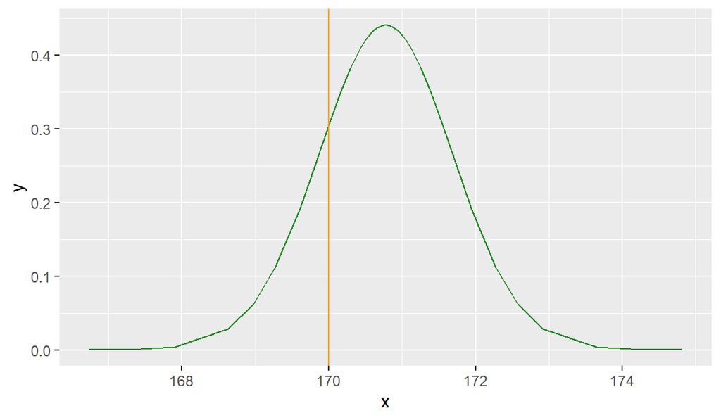

```r
inla_estimate_wif$marginals.fixed$`(Intercept)` %>%
  as_tibble() %>%
  ggplot(aes(x,y)) +
  geom_line(colour="forestgreen") +
  geom_vline(xintercept=true_theta,colour="orange")
```

The posterior distribution can then be summarized, generally by its mean (`mean`) or median (`0.5quant`) and by its 2.5th and 97.5th percentiles (`0.025quant` and `0.975quant`) constituting the **95% credible interval**. Contrary to the 95% confidence interval in frequentist inference, the 95% credible interval has a direct and easy interpretation: there is a 95% probability that the parameter value lies within its bounds. Other outputs such as `sd` and `mode` are less useful. The Kullback-Leibler divergence (`kld`) describes the difference between the Gaussian and the simplified or full Laplace approximations for each posterior (it should be close to 0).

There are also the model **hyperparameters**. In this case, there is only “precision for the Gaussian observations”. This refers to `true_sigma`, but on the precision scale (precision is the inverse of the variance).

```r
1/true_sigma^2
```

```
## [1] 0.01
```

# References

Gelman, Andrew, John B Carlin, Hal S Stern, and Donald B Rubin. 1995. *Bayesian Data Analysis*. Chapman; Hall/CRC.

Gómez-Rubio, Virgilio. 2021. *Bayesian Inference with INLA*. http://becarioprecario.bitbucket.io/inla-gitbook/index.html.

McElreath, Richard. 2016. *Statistical Rethinking: A Bayesian Course with Examples in R and Stan*. New York: Chapman; Hall/CRC. https://doi.org/10.1201/9781315372495.

Rue, Håvard, Sara Martino, and Nicolas Chopin. 2009. “Approximate Bayesian Inference for Latent Gaussian Models by Using Integrated Nested Laplace Approximations.” *Journal of the Royal Statistical Society Series B: Statistical Methodology* 71 (2): 319–92.